# Final Project

## Problem Statement

For our project, we aim to develop a machine learning model to predict medical test outcomes ("Normal," "Abnormal," or "Inconclusive") using a synthetic healthcare dataset. The dataset includes a variety of patient information relevant to healthcare analytics, such as medical conditions, test results, and treatment details.

We will begin with data preprocessing and exploratory data analysis to understand the characteristics and distributions within the data. Subsequently, we will evaluate and compare different machine learning models that were discussed in our class, focusing on optimizing them through careful hyperparameter tuning. We will assess the performance of these models using metrics such as accuracy and F1-scordents.

### Data: [Link](https://www.kaggle.com/datasets/prasad22/healthcare-dataset/)

The synthetic healthcare dataset available on Kaggle is designed as a training ground for data science, machine learning, and healthcare analytics, simulating real-world healthcare data while adhering to privacy standards. It includes a variety of data types and categories, such as patient names, ages, medical conditions, and test results, enabling users to practice data manipulation, predictive modeling, and data visualization. This dataset is ideal for those looking to develop and test healthcare models, enhance data cleaning skills, and explore healthcare trends through visualizations, addressing challenges like imbalanced classes and sensitive data handling.

#### Importing libraries and notebook config

```python
import pandas as pd
import numpy as np
import matplotlib.pyplot as plt
import seaborn as sns
from scipy import stats
from sklearn.preprocessing import MinMaxScaler, StandardScaler, RobustScaler
from sklearn.model_selection import train_test_split
import os
import joblib
import numpy as np
import pandas as pd
from sklearn.ensemble import GradientBoostingClassifier, RandomForestClassifier
from sklearn.metrics import accuracy_score, f1_score, mean_squared_error, mean_absolute_error, precision_score, recall_score
import tensorflow as tf
from tensorflow.keras.models import Sequential
from tensorflow.keras.layers import Dense, Dropout
from tensorflow.keras.callbacks import ModelCheckpoint
from sklearn.metrics import roc_curve, auc, RocCurveDisplay
from sklearn.preprocessing import label_binarize
from sklearn.multiclass import OneVsRestClassifier
from sklearn.metrics import confusion_matrix



# Notebook configuratonn and supperessing module/package warnings
import warnings
import logging
# Display all rows and columns
pd.set_option('display.max_rows', None)
pd.set_option('display.max_columns', None)
warnings.filterwarnings("ignore")
warnings.filterwarnings("ignore", message="Some non-default generation parameters")

logging.getLogger('tensorflow').setLevel(logging.ERROR)  # Hide warnings and info messages from TensorFlow
tf.compat.v1.logging.set_verbosity(tf.compat.v1.logging.ERROR)  # Hide warnings and info messages


# Create directory for saving models if it doesn't exist
model_dir = "./models"
if not os.path.exists(model_dir):
    os.makedirs(model_dir)
```

## Loading Data, cleaning and EDA

```python
data = pd.read_csv("./healthcare_dataset.csv")
data.head()
```

|  | Name | Age | Gender | Blood Type | Medical Condition | Date of Admission | Doctor | Hospital | Insurance Provider | Billing Amount | Room Number | Admission Type | Discharge Date | Medication | Test Results |
| --- | --- | --- | --- | --- | --- | --- | --- | --- | --- | --- | --- | --- | --- | --- | --- |
| 0 | Tiffany Ramirez | 81 | Female | O- | Diabetes | 2022-11-17 | Patrick Parker | Wallace-Hamilton | Medicare | 37490.983364 | 146 | Elective | 2022-12-01 | Aspirin | Inconclusive |
| 1 | Ruben Burns | 35 | Male | O+ | Asthma | 2023-06-01 | Diane Jackson | Burke, Griffin and Cooper | UnitedHealthcare | 47304.064845 | 404 | Emergency | 2023-06-15 | Lipitor | Normal |
| 2 | Chad Byrd | 61 | Male | B- | Obesity | 2019-01-09 | Paul Baker | Walton LLC | Medicare | 36874.896997 | 292 | Emergency | 2019-02-08 | Lipitor | Normal |
| 3 | Antonio Frederick | 49 | Male | B- | Asthma | 2020-05-02 | Brian Chandler | Garcia Ltd | Medicare | 23303.322092 | 480 | Urgent | 2020-05-03 | Penicillin | Abnormal |
| 4 | Mrs. Brandy Flowers | 51 | Male | O- | Arthritis | 2021-07-09 | Dustin Griffin | Jones, Brown and Murray | UnitedHealthcare | 18086.344184 | 477 | Urgent | 2021-08-02 | Paracetamol | Normal |

```python
# Checking number rows and columns of data
data.shape
```

```
(10000, 15)
```

```python
# Checking column names of data
data.columns
```

```
Index(['Name', 'Age', 'Gender', 'Blood Type', 'Medical Condition',
       'Date of Admission', 'Doctor', 'Hospital', 'Insurance Provider',
       'Billing Amount', 'Room Number', 'Admission Type', 'Discharge Date',
       'Medication', 'Test Results'],
      dtype='object')
```

```python
#Dataset info
data.info()
```

```
<class 'pandas.core.frame.DataFrame'>
RangeIndex: 10000 entries, 0 to 9999
Data columns (total 15 columns):
 #   Column              Non-Null Count  Dtype
---  ------              --------------  -----
 0   Name                10000 non-null  object
 1   Age                 10000 non-null  int64
 2   Gender              10000 non-null  object
 3   Blood Type          10000 non-null  object
 4   Medical Condition   10000 non-null  object
 5   Date of Admission   10000 non-null  object
 6   Doctor              10000 non-null  object
 7   Hospital            10000 non-null  object
 8   Insurance Provider  10000 non-null  object
 9   Billing Amount      10000 non-null  float64
 10  Room Number         10000 non-null  int64
 11  Admission Type      10000 non-null  object
 12  Discharge Date      10000 non-null  object
 13  Medication          10000 non-null  object
 14  Test Results        10000 non-null  object
dtypes: float64(1), int64(2), object(12)
memory usage: 1.1+ MB
```

```python
# Dataset breif stats
data.describe()
```

|  | Age | Billing Amount | Room Number |
| --- | --- | --- | --- |
| count | 10000.000000 | 10000.000000 | 10000.000000 |
| mean | 51.452200 | 25516.806778 | 300.082000 |
| std | 19.588974 | 14067.292709 | 115.806027 |
| min | 18.000000 | 1000.180837 | 101.000000 |
| 25% | 35.000000 | 13506.523967 | 199.000000 |
| 50% | 52.000000 | 25258.112566 | 299.000000 |
| 75% | 68.000000 | 37733.913727 | 400.000000 |
| max | 85.000000 | 49995.902283 | 500.000000 |

```python
#stats for catergorical data
data.describe(include = 'O')
```

|  | Name | Gender | Blood Type | Medical Condition | Date of Admission | Doctor | Hospital | Insurance Provider | Admission Type | Discharge Date | Medication | Test Results |
| --- | --- | --- | --- | --- | --- | --- | --- | --- | --- | --- | --- | --- |
| count | 10000 | 10000 | 10000 | 10000 | 10000 | 10000 | 10000 | 10000 | 10000 | 10000 | 10000 | 10000 |
| unique | 9378 | 2 | 8 | 6 | 1815 | 9416 | 8639 | 5 | 3 | 1834 | 5 | 3 |
| top | Michael Johnson | Female | AB- | Asthma | 2019-04-12 | Michael Johnson | Smith PLC | Cigna | Urgent | 2021-11-28 | Penicillin | Abnormal |
| freq | 7 | 5075 | 1275 | 1708 | 15 | 7 | 19 | 2040 | 3391 | 14 | 2079 | 3456 |

```python
df = data.copy()
```

### Data Cleaning

```python
# Makking sure dates are in correct format
df['Date of Admission'] = pd.to_datetime(df['Date of Admission'])
df['Discharge Date'] = pd.to_datetime(df['Discharge Date'])
```

```python
#check for NULL values if any in each column
df.isnull().sum()
```

```
Name                  0
Age                   0
Gender                0
Blood Type            0
Medical Condition     0
Date of Admission     0
Doctor                0
Hospital              0
Insurance Provider    0
Billing Amount        0
Room Number           0
Admission Type        0
Discharge Date        0
Medication            0
Test Results          0
dtype: int64
```

```python
#check if there are duplicate records in the data
df.duplicated().sum()
```

```
0
```

```python
#calculate the no: of days patients got admitted in hospital
df['Days Hospitalized'] = (df['Discharge Date'] - df['Date of Admission']).dt.days
df['Days Hospitalized'] = df['Days Hospitalized'].astype(int)
df['Days Hospitalized'].head()
```

```
0    14
1    14
2    30
3     1
4    24
Name: Days Hospitalized, dtype: int32
```

```python
#drop columns irrelevant to our analysis
df = df.drop(columns = ['Name','Date of Admission','Discharge Date','Room Number', 'Doctor', 'Hospital', 'Insurance Provider'])
df.columns
```

```
Index(['Age', 'Gender', 'Blood Type', 'Medical Condition', 'Billing Amount',
       'Admission Type', 'Medication', 'Test Results', 'Days Hospitalized'],
      dtype='object')
```

```
____________________________________________________________________________________________________
```

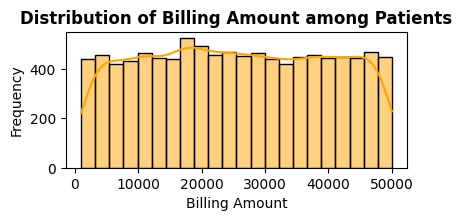

```
____________________________________________________________________________________________________
```

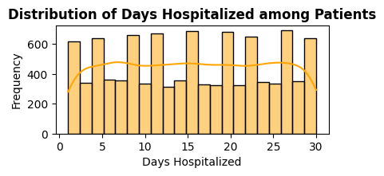

```python
#plotting histograms to find the frequency of numeric columns (age, billing amount and days hospitalized)
for col in df.columns:
    if df[col].dtype == 'int' or df[col].dtype == 'float':
        plt.figure(figsize = (15,6))
        plt.style.use('seaborn-v0_8-dark-palette')
        plt.subplot(3,3,3)
        sns.histplot(df[col],kde = True,color = 'orange')
        plt.ylabel('Frequency',fontsize = 10)
        plt.xlabel(col,fontsize = 10)
        plt.title(f'Distribution of {col} among Patients',fontsize = 12,weight = 'bold')
        print("_"*100)
        plt.show()
```

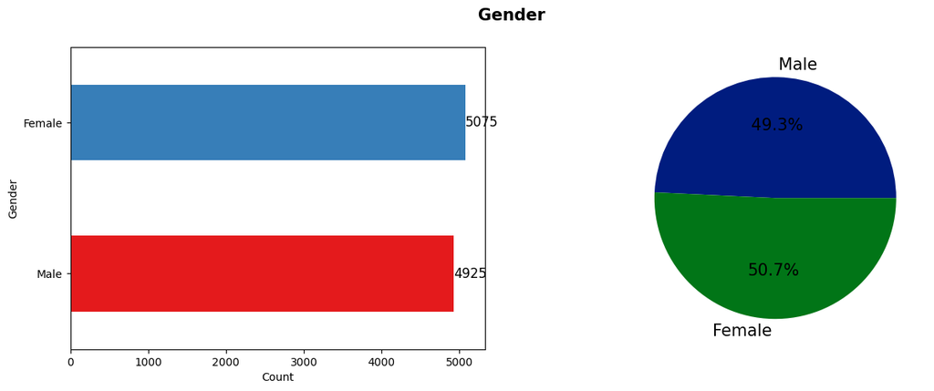

```
____________________________________________________________________________________________________
```

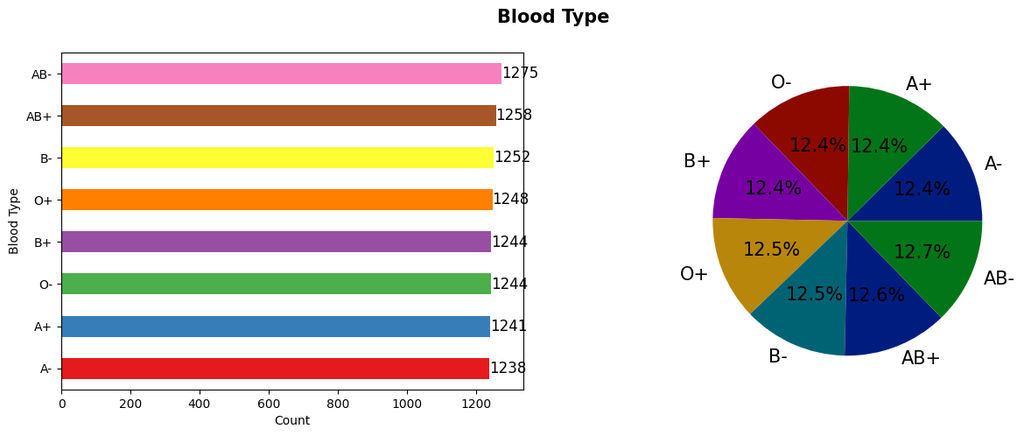

```
____________________________________________________________________________________________________
```

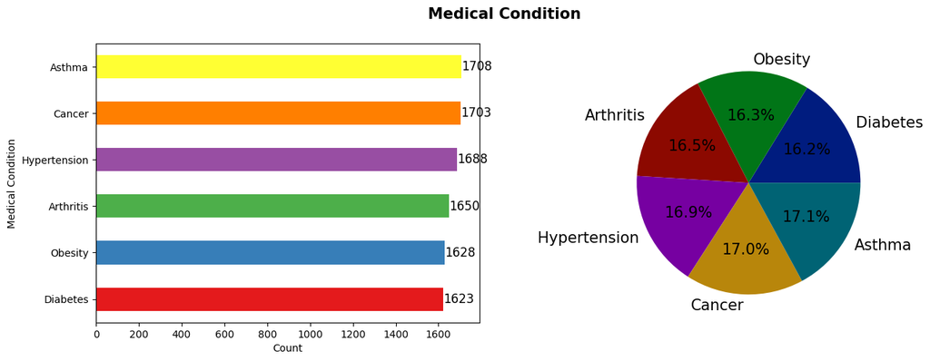

```
____________________________________________________________________________________________________
```

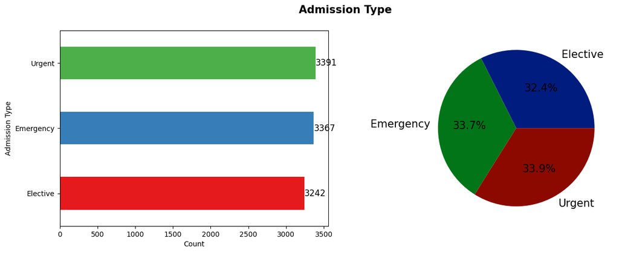

```
____________________________________________________________________________________________________
```

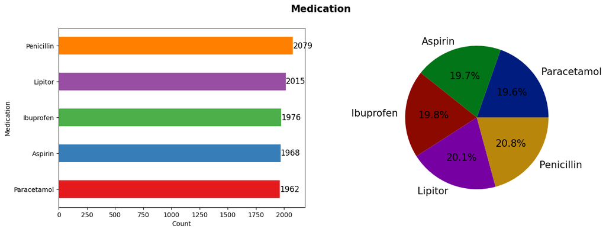

```
____________________________________________________________________________________________________
```

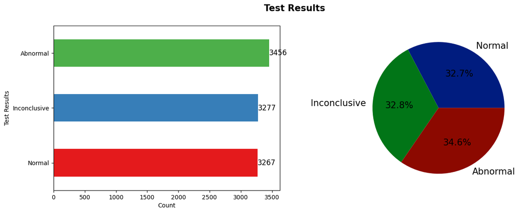

```
____________________________________________________________________________________________________
```

```python
#plotting pie chart and bar chart to find the data distribution for categorical columns

for col in df.columns:
    if df[col].dtype == 'O' and col != 'Doctor' and col!= 'Hospital':
        print('\n')
        fig,ax = plt.subplots(1,2,figsize = (15,5))
        fig.suptitle(col,fontsize = 15,weight = 'bold')
        plt.subplot(1,2,1)
        category_count = df[col].value_counts().sort_values()
        category_count.plot(kind = 'barh',color= plt.cm.Set1.colors)
        for index,value in enumerate(category_count):
            plt.text(value,index,str(value),fontsize = 12,va = 'center')
        plt.xlabel('Count')
        plt.subplot(1,2,2)
        category_count.plot(kind = 'pie',
               labels = category_count.index,
               autopct = '%1.1f%%',
               textprops = {'fontsize':15})
        plt.ylabel('')
        plt.show()
        print("_"*100)
```

#### What is the distribution of medical condtions between genders?

```python
#function converts the data into 2 dimensional
gender_medical = df.groupby(['Medical Condition','Gender']).size().sort_values().unstack()
gender_medical
```

| Gender Medical Condition | Female | Male |
| --- | --- | --- |
| Arthritis | 815 | 835 |
| Asthma | 874 | 834 |
| Cancer | 887 | 816 |
| Diabetes | 825 | 798 |
| Hypertension | 836 | 852 |
| Obesity | 838 | 790 |

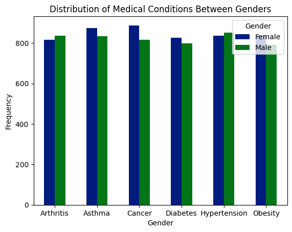

```python
#distribution chart
gender_medical.plot(kind = 'bar')
plt.title('Distribution of Medical Conditions Between Genders')
plt.xlabel('Gender')
plt.ylabel('Frequency')
plt.xticks(rotation = 0)
plt.show()
```

#### Interpretation

- Female have higher share in majority of the medical conditions. Cancer is leading medical condition among female whereas Hypertension is leading cause among male.

#### What is the correlation between age,billing amount and days hospitalized?

```python
# selecting the columns to correlate
correlation_columns = ['Age','Billing Amount','Days Hospitalized']

# creating a df using the above columns
correlate_df = df[correlation_columns]

#encoding categorical columns for correlation
correlate_df['Gender'] = df['Gender'].astype('category').cat.codes
correlate_df['Admission Type'] = df['Admission Type'].astype('category').cat.codes
correlate_df['Test Results'] = df['Test Results'].astype('category').cat.codes

# creating correlation matrix
correlation_matrix = correlate_df.corr()
correlation_matrix
```

|  | Age | Billing Amount | Days Hospitalized | Gender | Admission Type | Test Results |
| --- | --- | --- | --- | --- | --- | --- |
| Age | 1.000000 | -0.009483 | 0.009111 | -0.008099 | 0.003233 | 0.008747 |
| Billing Amount | -0.009483 | 1.000000 | -0.013507 | 0.002340 | 0.002531 | -0.005844 |
| Days Hospitalized | 0.009111 | -0.013507 | 1.000000 | -0.006361 | -0.005942 | -0.008228 |
| Gender | -0.008099 | 0.002340 | -0.006361 | 1.000000 | -0.004515 | -0.010472 |
| Admission Type | 0.003233 | 0.002531 | -0.005942 | -0.004515 | 1.000000 | -0.010964 |
| Test Results | 0.008747 | -0.005844 | -0.008228 | -0.010472 | -0.010964 | 1.000000 |

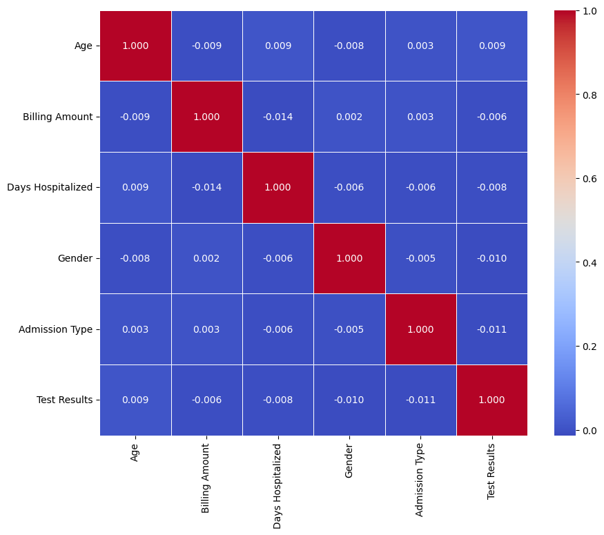

```python
#plotting correlation matrix using heatmap
plt.figure(figsize = (10,8))
sns.heatmap(correlation_matrix,annot = True,cmap = 'coolwarm',fmt = '.3f',linewidths = 0.5)
plt.show()
```

#### Interpretation

- There is a slight correlation between age and test results. Even there is a positive correlation between age and days hospitalized. There is a negative correlation between age and billing amount.
- Billing amount has negative correlation with test results and days hospitalized. Billing amount has a positive correlation with admission type and gender.
- Days hospitalized has negative correlation with every attribute except age.
- Except for billing amount attribute, gender has a negative correlation with all other attributes.
- Admission type and test results have a negative correlation.

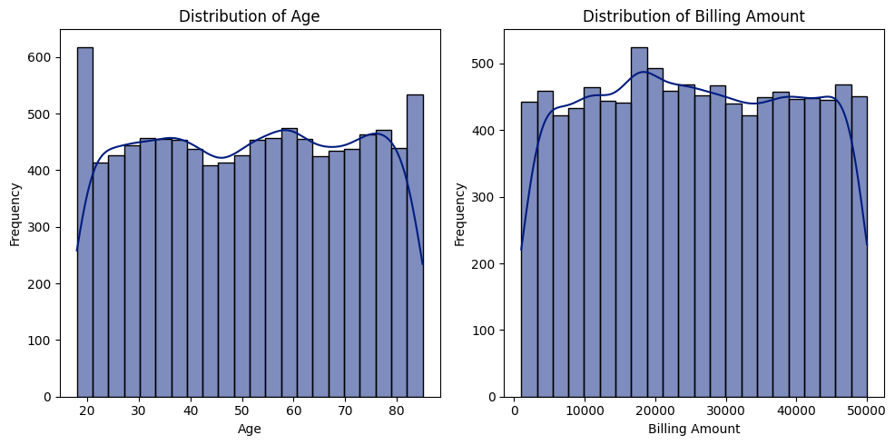

```python
# Create a figure and axes with 1 row and 3 columns
fig, axes = plt.subplots(nrows=1, ncols=2, figsize=(10, 5))  # Adjust figsize as needed

# Iterate over the number of axes and numerical variables to create histogram on each subplot
for ax, column in zip(axes, ['Age', 'Billing Amount']):  # Limit to the first 3 for a 1x3 grid
    sns.histplot(df[column], kde=True, ax=ax)
    ax.set_title(f'Distribution of {column}')
    ax.set_xlabel(column)
    ax.set_ylabel('Frequency')

# Adjust layout to prevent overlap
plt.tight_layout()

# Show the plot
plt.show()
```

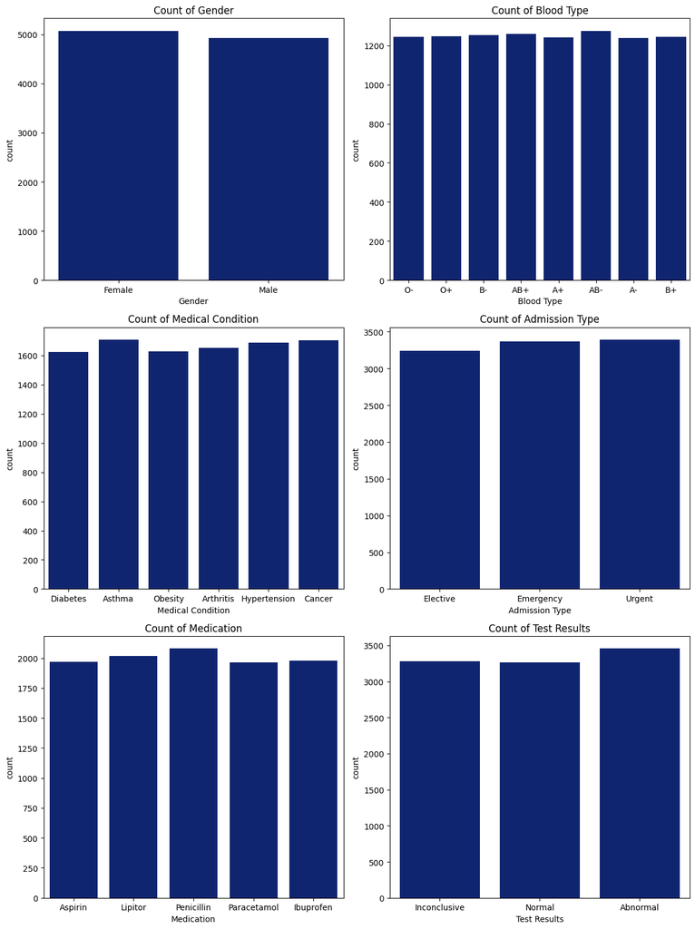

```python
categorical_columns = [
    'Gender', 'Blood Type', 'Medical Condition',
    'Admission Type', 'Medication', 'Test Results'
]

# Set up the plotting grid
fig, axes = plt.subplots(3, 2, figsize=(12, 16))

# Flatten the axes array to simplify indexing
axes = axes.flatten()

# Iterate over categorical variables and create count plots
for i, col in enumerate(categorical_columns):
    sns.countplot(x=col, data=df, ax=axes[i])
    axes[i].set_title(f'Count of {col}')

# Adjust layout to prevent overlap
plt.tight_layout()
plt.show()
```

### Checking for Outliers(if any):

```python
numerical_columns = ['Age', 'Billing Amount']

# Calculate Q1, Q2 (median), Q3, and IQR for each column
Q1 = df[numerical_columns].quantile(0.25)
Q2 = df[numerical_columns].median()
Q3 = df[numerical_columns].quantile(0.75)
IQR = Q3 - Q1

# Count outliers for each column
outliers = ((df[numerical_columns] < (Q1 - 1.5 * IQR)) | (df[numerical_columns] > (Q3 + 1.5 * IQR)))
outliers_count = outliers.sum()

# Create a summary table
outliers_table = pd.DataFrame({
    'Min': df[numerical_columns].min(),
    'Q1': Q1,
    'Median': Q2,
    'Q3': Q3,
    'Max': df[numerical_columns].max(),
    'IQR': IQR,
    'Outliers Count': outliers_count,
})

# Print the outliers table
outliers_table
```

|  | Min | Q1 | Median | Q3 | Max | IQR | Outliers Count |
| --- | --- | --- | --- | --- | --- | --- | --- |
| Age | 18.000000 | 35.000000 | 52.000000 | 68.000000 | 85.000000 | 33.00000 | 0 |
| Billing Amount | 1000.180837 | 13506.523967 | 25258.112566 | 37733.913727 | 49995.902283 | 24227.38976 | 0 |

```python
numerical_columns = ['Age', 'Billing Amount']

# Calculate Z-scores
z_scores = stats.zscore(df[numerical_columns])

# Convert to a DataFrame
z_scores_df = pd.DataFrame(z_scores, columns=numerical_columns)

# Filter for rows where any column has a Z-score greater than 3 or less than -3
outliers = z_scores_df[(np.abs(z_scores_df) > 3).any(axis=1)]

# Display the outliers
outliers
```

|  | Age | Billing Amount |
| --- | --- | --- |

```python
df[(df['Age'] < 0) & (df['Age'] > 100)]
```

|  | Age | Gender | Blood Type | Medical Condition | Billing Amount | Admission Type | Medication | Test Results | Days Hospitalized |
| --- | --- | --- | --- | --- | --- | --- | --- | --- | --- |